# Assignment 2

Jonathan Lee

September 23rd, 2020

```r
library(ggplot2)
library(sf)
library(rnaturalearth)
library(tidyverse)
library(ggspatial)
library(cartogram)
library(ggthemes)
library(magrittr)
library(tidycensus)
library(cartogram)
library(wesanderson)
library(gridExtra)
```

## Baseline Map

### This is the baseline map of the US and its states using the R naturalearth package. I chose to not show the states Alaska and Hawaii on this map and the following examples.

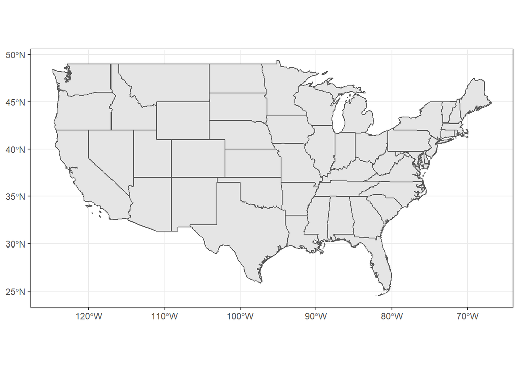

```r
US_states <- ne_states(country = "United States of America",
                       returnclass = "sf") %>%
  filter(name != "Alaska",
         name != "Hawaii")


US_map <- ggplot(US_states) +
  geom_sf() +
  theme_bw()

US_map
```

## Map Projection #1

### This map is a projection using NAD83 Albers Equal Area of California.

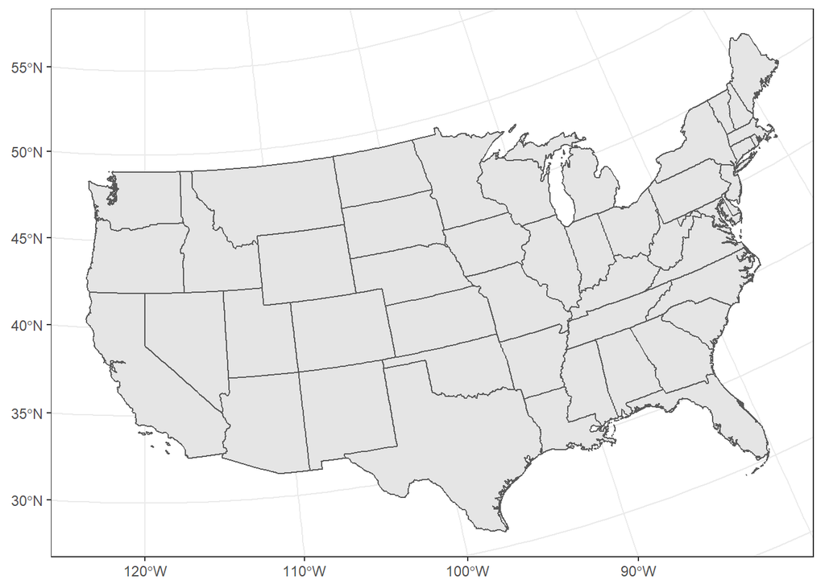

```r
CA_state_plane <- "+proj=aea +lat_1=34 +lat_2=40.5 +lat_0=0 +lon_0=-120 +x_0=0 +y_0=-4000000 +ellps=GRS80 +datum=NAD83 +units=m +no_defs"

US_map <- ggplot(US_states) +
  geom_sf() +
  coord_sf(crs = CA_state_plane)+
  theme_bw()

US_map
```

## Map Projection #2

### This map is a projection using the NAD83 of Texas.

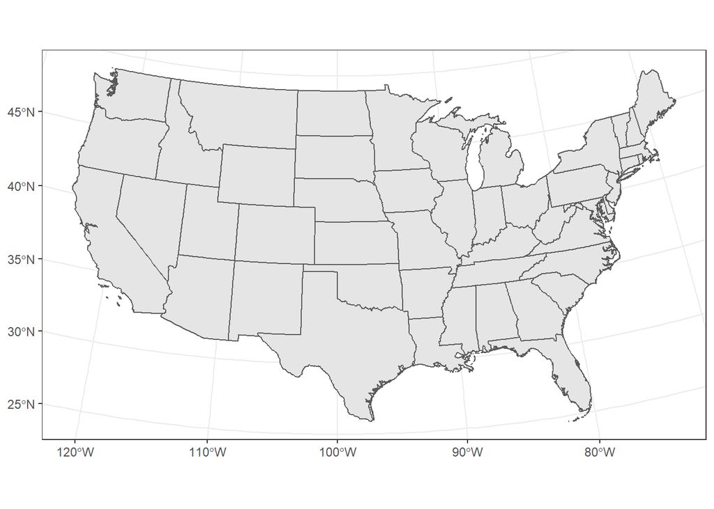

```r
TX_state_plane <-"+proj=lcc +lat_1=27.41666666666667 +lat_2=34.91666666666666 +lat_0=31.16666666666667 +lon_0=-100 +x_0=1000000 +y_0=1000000 +ellps=GRS80 +datum=NAD83 +units=m +no_defs"

US_map <- ggplot(US_states) +
  geom_sf() +
  coord_sf(crs = TX_state_plane)+
  theme_bw()

US_map
```

## Map Projection #3

### This map is a projection using the NAD83 of Massachusetts

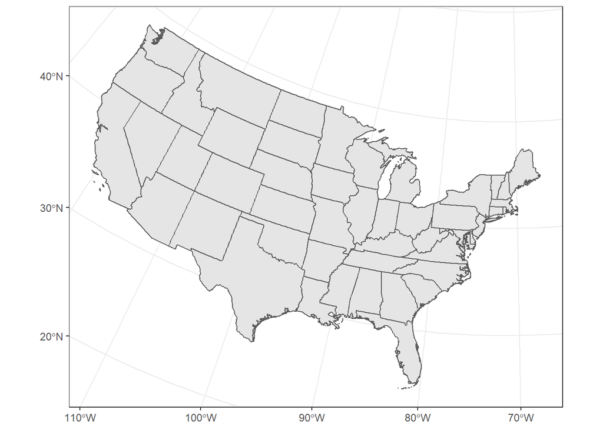

```r
MA_state_plane <- "+proj=lcc +lat_1=42.68333333333333 +lat_2=41.71666666666667 +lat_0=41 +lon_0=-71.5 +x_0=200000.0001016002 +y_0=750000 +ellps=GRS80 +datum=NAD83 +to_meter=0.3048006096012192 +no_defs"

US_map <- ggplot(US_states) +
  geom_sf() +
  coord_sf(crs = MA_state_plane)+
  theme_bw()

US_map
```

## Map Projection #4

### This is a projection of the US using Albers Equal Area conical projection of Brazil. You can see the conical warping of the US.

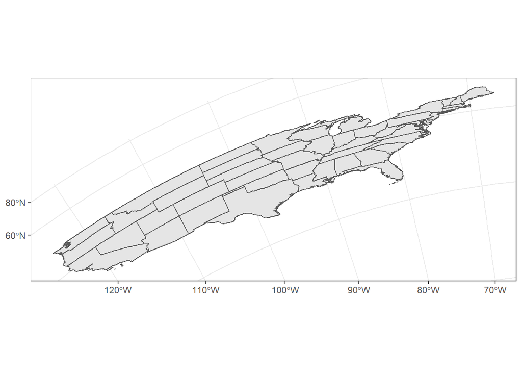

```r
brazil <- "+proj=aea +lat_1=-27 +lat_2=-34 +lat_0=-24 +lon_0=-54 +x_0=0 +y_0=0 +ellps=GRS80 +units=m +no_defs"

US_map <- ggplot(US_states) +
  geom_sf() +
  coord_sf(crs = brazil)+
  theme_bw()

US_map
```

## Map Projection #5

### For the purposes of the next few examples, I will use the projection of the US as a whole using the Albers Equal Area projection.

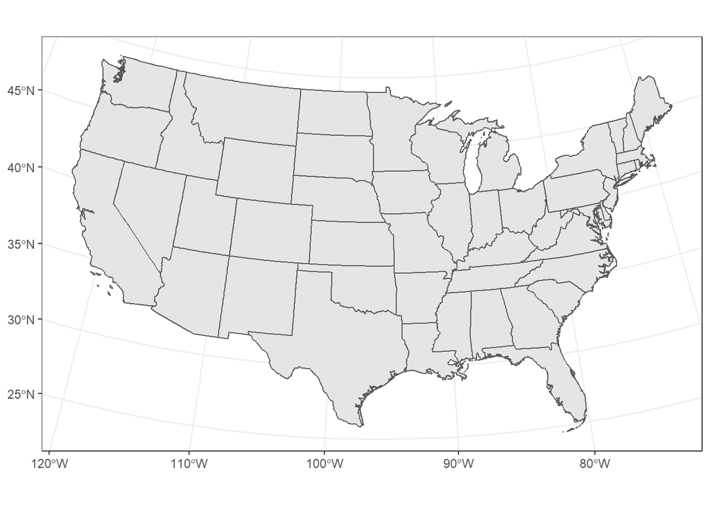

```r
USA_AEA <- "+proj=aea +lat_1=29.5 +lat_2=45.5 +lat_0=23 +lon_0=-96 +x_0=0 +y_0=0 +ellps=clrk66 +units=m +no_defs"

US_transformed <- US_states %>%
  st_transform(crs = USA_AEA)

ggplot(US_transformed) +
  geom_sf()+
  theme_bw()
```

## Chloropleth Map

### This map shows the total population of each state from the 2018 American Community Survey results.

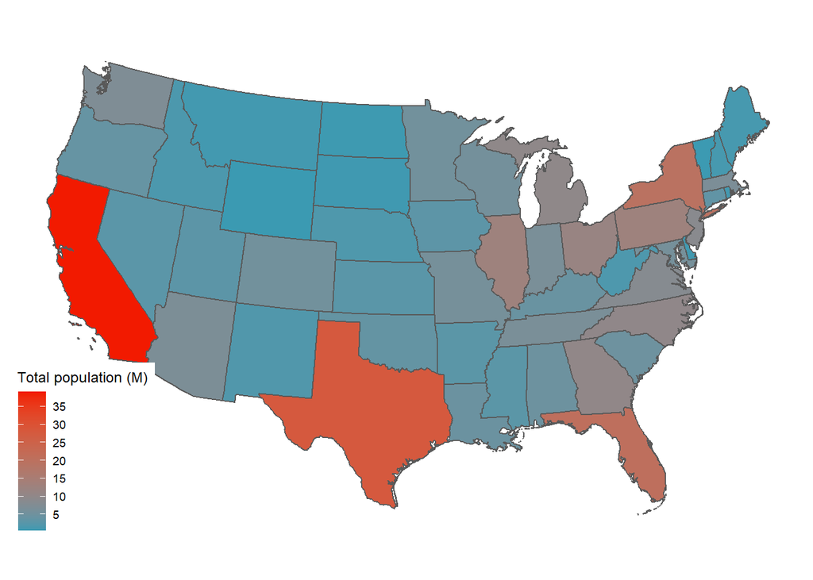

```r
census_data <- get_acs(geography = "state", variables = "B01003_001", year = 2018)


US_data <- left_join(US_transformed, census_data, by = c("name" = "NAME"))

ggplot(US_data, aes(fill = estimate/1000000)) +
  geom_sf()+
  scale_fill_gradientn(name = "Total population (M)",
                       breaks = seq(0,40, by = 5),
                       labels = seq(0,40, by = 5),
                       colors = wes_palette(name = "Zissou1",n = 2, type = "continuous"))+
  theme_map()
```

## Chloropleth Map Comparison

### I wanted to see how the map would look if I added three colors to the gradient instead of two.

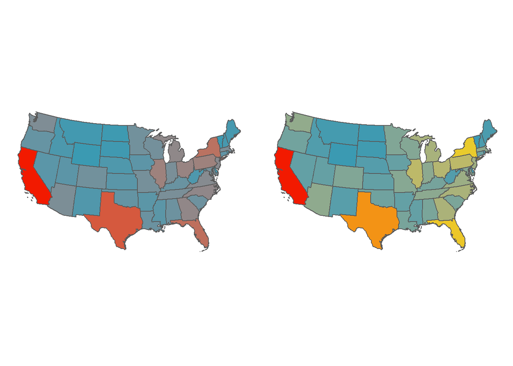

```r
plot_2 <- ggplot(US_data, aes(fill = estimate/1000000)) +
  geom_sf()+
  scale_fill_gradientn(
                       colors = wes_palette(name = "Zissou1",n = 2, type = "continuous"),
                       guide = FALSE)+
  theme_map()

plot_3 <- ggplot(US_data, aes(fill = estimate/1000000)) +
  geom_sf()+
  scale_fill_gradientn(name = "Total population (M)",
                       breaks = seq(0,40, by = 5),
                       labels = seq(0,40, by = 5),
                       colors = wes_palette(name = "Zissou1",n = 3, type = "continuous"),
                       guide = FALSE)+
  theme_map()


grid.arrange(plot_2, plot_3, nrow=1)
```

## Cartogram Map

### This map shows the total population of each state and the distortion to its size depending on the population.

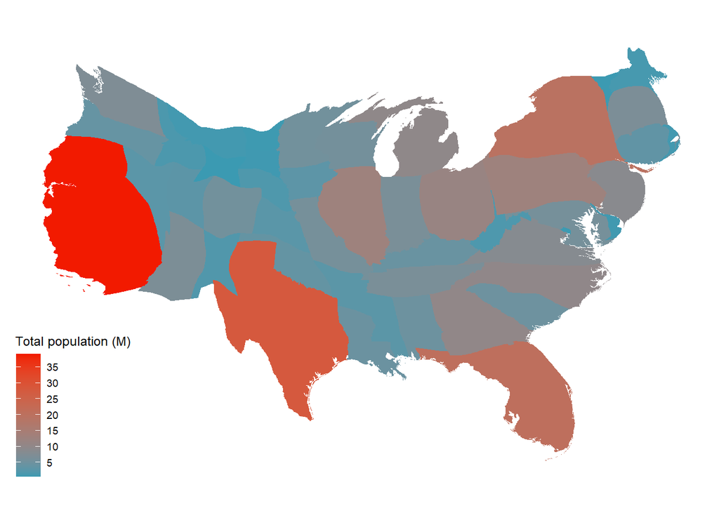

```r
US_cartogram <- cartogram_cont(US_data, "estimate", itermax = 5)

ggplot(US_cartogram, aes(fill = estimate/1000000))+
  geom_sf(color = NA)+
  scale_fill_gradientn(name = "Total population (M)",
                       breaks = seq(0,40, by = 5),
                       labels = seq(0,40, by = 5),
                       colors = wes_palette(name = "Zissou1", n = 2, type = "continuous"))+
  theme_map()
```

## Dorling Map

### This map shows the size of the population of each state as its own bubble in the location of the state.

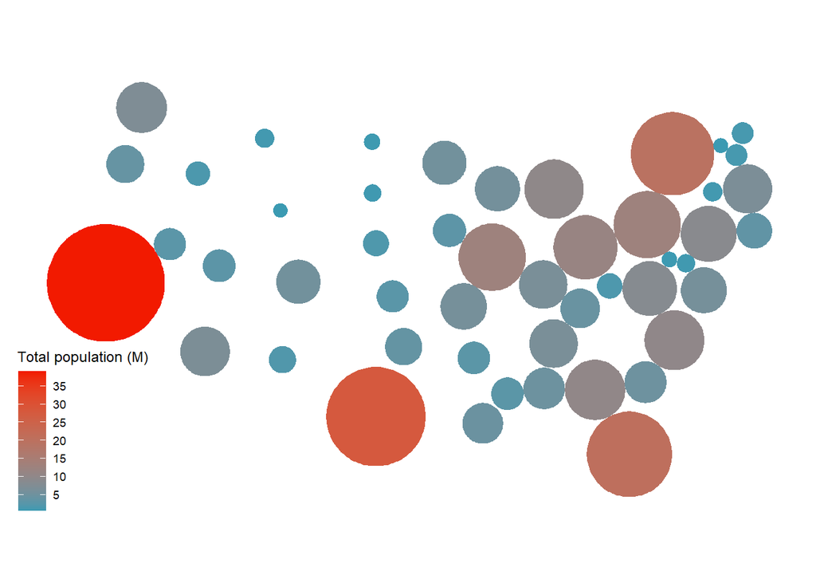

```r
US_dorling <- cartogram_dorling(US_data, "estimate")

ggplot(US_dorling, aes(fill = estimate/1000000))+
  geom_sf(color = NA)+
  scale_fill_gradientn(name = "Total population (M)",
                       breaks = seq(0,40, by = 5),
                       labels = seq(0,40, by = 5),
                       colors = wes_palette(name = "Zissou1", n = 2, type = "continuous"))+
  theme_map()
```

## Centroid Map

### This map shows the size of the population of each state in the center of the state’s geographical location.

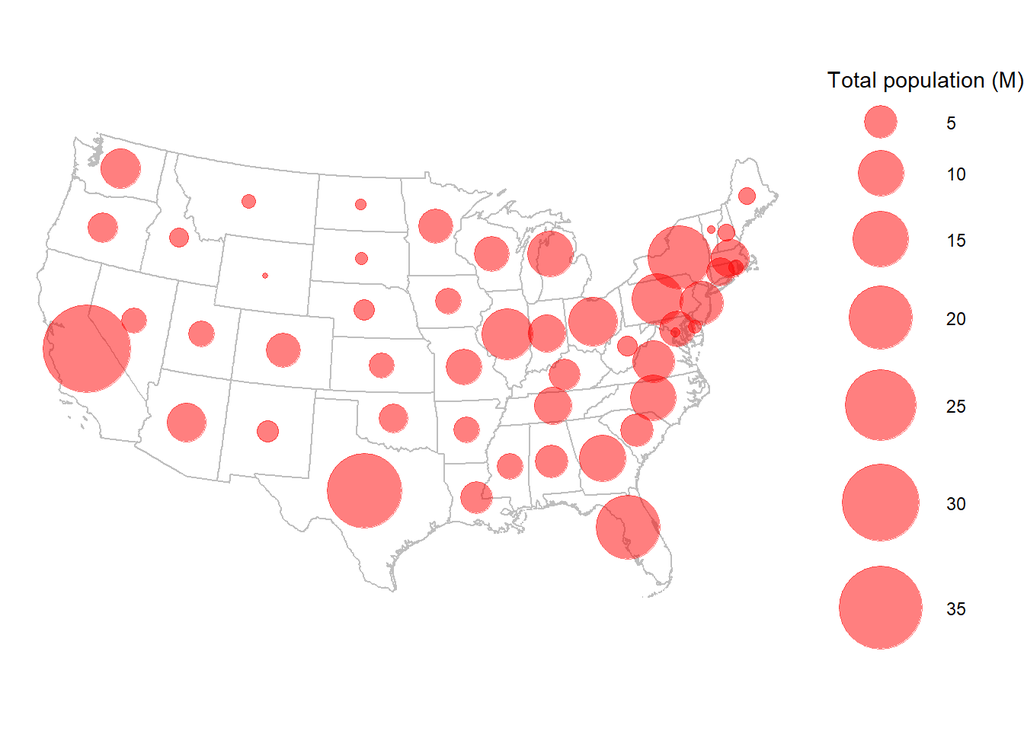

```r
US_centroids <- st_centroid(US_data)

ggplot(US_data) +
  geom_sf(fill = NA, color = "gray")+
  geom_sf(data = US_centroids, aes(size = estimate/1000000),
          alpha = 0.5, color = "red") +
  scale_size_continuous(name = "Total population (M)",
                        range = c(1,20),
                        breaks = seq(0,40, by = 5),
                        labels = seq(0,40, by = 5)) +
  theme_void()
```